# Analysis: Linear Models

## Introduction

This markdown imports the processed analysis data and uses the tidymodels framework to fit linear models. Follow the previous markdowns to generate the data.

This analysis examines the predictors of allocation of FEMA funds during disaster declarations. The following definitions exist for the analysis:

- The two outcomes of interest are Requested Amount (`ReqAmt`) and Obligated Amount (`OblAmt`).
- The primary predictor of interest is Incident Duration (`IncidentDuration`)
- Whichever outcome is not currently fitted to the model will *not* be considered a predictor of interest
- The outcomes of interest are log-transformed

For each outcome of interest, the following steps will be completed:

1. Fit a simple linear regression with the primary predictor of interest
2. Fit a multivariable linear regression
3. Comparison of the two models

## Required Packages

The following R packages are required for this script:

- here: for path setting
- tidyverse: for all packages in the Tidyverse (ggplot2, dyplr, tidyr, readr, purr, tibble, stringr, forcats)
- skimr: for data summarization
- tidymodels: for data modeling

## Load Processed Data

Load the data generated from the markdowns in the `processing_code` folder.

```r
#define file path to req data
data_location_req <- here::here("data", "processed_data", "analysisdata-RA.rds")

#load req data
analysis_data_req <- readRDS(data_location_req)

#define file path to obl data
data_location_obl <- here::here("data", "processed_data", "analysisdata-OA.rds")

#load obl data
analysis_data_obl <- readRDS(data_location_obl)
```

## Data Overview

```r
skimr::skim(analysis_data_req)
```

Data summary

| Name | analysis_data_req |
| --- | --- |
| Number of rows | 326 |
| Number of columns | 23 |
| _______________________ |  |
| Column type frequency: |  |
| character | 5 |
| factor | 4 |
| numeric | 14 |
| ________________________ |  |
| Group variables | None |

**Variable type: character**

| skim_variable | n_missing | complete_rate | min | max | empty | n_unique | whitespace |
| --- | --- | --- | --- | --- | --- | --- | --- |
| state | 0 | 1 | 2 | 2 | 0 | 51 | 0 |
| FEMARegion | 0 | 1 | 8 | 11 | 0 | 10 | 0 |
| declarationType | 0 | 1 | 2 | 2 | 0 | 2 | 0 |
| declarationTitle | 0 | 1 | 8 | 81 | 0 | 100 | 0 |
| incidentType | 0 | 1 | 4 | 16 | 0 | 9 | 0 |

**Variable type: factor**

| skim_variable | n_missing | complete_rate | ordered | n_unique | top_counts |
| --- | --- | --- | --- | --- | --- |
| IncidentMonth | 0 | 1 | TRUE | 12 | Jan: 71, Oct: 41, Aug: 32, Sep: 31 |
| IH | 0 | 1 | FALSE | 2 | Not: 163, Awa: 163 |
| PA | 0 | 1 | FALSE | 2 | Awa: 318, Not: 8 |
| HM | 0 | 1 | FALSE | 2 | Awa: 260, Not: 66 |

**Variable type: numeric**

| skim_variable | n_missing | complete_rate | mean | sd | p0 | p25 | p50 | p75 | p100 | hist |
| --- | --- | --- | --- | --- | --- | --- | --- | --- | --- | --- |
| latitude | 0 | 1 | 37.82 | 7.19 | 18.22 | 33.84 | 37.96 | 43.19 | 63.59 | ▁▆▇▁▁ |
| longitude | 0 | 1 | -93.67 | 18.41 | -155.67 | -99.90 | -91.83 | -81.16 | -66.59 | ▁▁▂▇▇ |
| Population | 0 | 1 | 9313643.01 | 10333562.39 | 576851.00 | 3011524.00 | 5706494.00 | 10439388.00 | 39538223.00 | ▇▂▁▁▁ |
| Counties | 0 | 1 | 75.26 | 53.47 | 1.00 | 46.00 | 67.00 | 88.00 | 254.00 | ▃▇▁▁▁ |
| disasterNumber | 0 | 1 | 4157.55 | 392.84 | 3346.00 | 4080.25 | 4276.50 | 4457.25 | 4619.00 | ▅▁▂▇▇ |
| IncidentYear | 0 | 1 | 2016.97 | 2.89 | 2012.00 | 2015.00 | 2017.00 | 2020.00 | 2021.00 | ▅▃▅▅▇ |
| IncidentDuration | 0 | 1 | 135.66 | 250.30 | 0.00 | 5.00 | 14.00 | 46.25 | 660.00 | ▇▁▁▁▂ |
| ResponseDays | 0 | 1 | 1404.07 | 898.44 | 70.04 | 660.00 | 1178.54 | 2066.51 | 3588.00 | ▇▅▅▃▂ |
| IH_pct | 0 | 1 | 0.34 | 1.59 | 0.00 | 0.00 | 0.00 | 0.24 | 27.69 | ▇▁▁▁▁ |
| PA_pct | 0 | 1 | 0.59 | 1.56 | 0.00 | 0.14 | 0.36 | 1.00 | 27.31 | ▇▁▁▁▁ |
| HM_pct | 0 | 1 | 0.48 | 1.56 | 0.00 | 0.04 | 0.21 | 0.60 | 27.25 | ▇▁▁▁▁ |
| TotalAgencies | 0 | 1 | 6.23 | 7.03 | 1.00 | 2.00 | 3.00 | 8.00 | 55.00 | ▇▂▁▁▁ |
| FEMACSAvg | 0 | 1 | 0.96 | 0.06 | 0.68 | 0.95 | 1.00 | 1.00 | 1.00 | ▁▁▁▂▇ |
| ReqAmt | 0 | 1 | 40601806.50 | 255138972.55 | 0.00 | 51024.33 | 420063.94 | 4751605.15 | 4388540486.39 | ▇▁▁▁▁ |

```r
skimr::skim(analysis_data_obl)
```

Data summary

| Name | analysis_data_obl |
| --- | --- |
| Number of rows | 326 |
| Number of columns | 23 |
| _______________________ |  |
| Column type frequency: |  |
| character | 5 |
| factor | 4 |
| numeric | 14 |
| ________________________ |  |
| Group variables | None |

**Variable type: character**

| skim_variable | n_missing | complete_rate | min | max | empty | n_unique | whitespace |
| --- | --- | --- | --- | --- | --- | --- | --- |
| state | 0 | 1 | 2 | 2 | 0 | 51 | 0 |
| FEMARegion | 0 | 1 | 8 | 11 | 0 | 10 | 0 |
| declarationType | 0 | 1 | 2 | 2 | 0 | 2 | 0 |
| declarationTitle | 0 | 1 | 8 | 81 | 0 | 100 | 0 |
| incidentType | 0 | 1 | 4 | 16 | 0 | 9 | 0 |

**Variable type: factor**

| skim_variable | n_missing | complete_rate | ordered | n_unique | top_counts |
| --- | --- | --- | --- | --- | --- |
| IncidentMonth | 0 | 1 | TRUE | 12 | Jan: 71, Oct: 41, Aug: 32, Sep: 31 |
| IH | 0 | 1 | FALSE | 2 | Not: 163, Awa: 163 |
| PA | 0 | 1 | FALSE | 2 | Awa: 318, Not: 8 |
| HM | 0 | 1 | FALSE | 2 | Awa: 260, Not: 66 |

**Variable type: numeric**

| skim_variable | n_missing | complete_rate | mean | sd | p0 | p25 | p50 | p75 | p100 | hist |
| --- | --- | --- | --- | --- | --- | --- | --- | --- | --- | --- |
| latitude | 0 | 1 | 37.82 | 7.19 | 18.22 | 33.84 | 37.96 | 43.19 | 63.59 | ▁▆▇▁▁ |
| longitude | 0 | 1 | -93.67 | 18.41 | -155.67 | -99.90 | -91.83 | -81.16 | -66.59 | ▁▁▂▇▇ |
| Population | 0 | 1 | 9313643.01 | 10333562.39 | 576851.00 | 3011524.00 | 5706494.00 | 10439388.00 | 39538223.00 | ▇▂▁▁▁ |
| Counties | 0 | 1 | 75.26 | 53.47 | 1.00 | 46.00 | 67.00 | 88.00 | 254.00 | ▃▇▁▁▁ |
| disasterNumber | 0 | 1 | 4157.55 | 392.84 | 3346.00 | 4080.25 | 4276.50 | 4457.25 | 4619.00 | ▅▁▂▇▇ |
| IncidentYear | 0 | 1 | 2016.97 | 2.89 | 2012.00 | 2015.00 | 2017.00 | 2020.00 | 2021.00 | ▅▃▅▅▇ |
| IncidentDuration | 0 | 1 | 135.66 | 250.30 | 0.00 | 5.00 | 14.00 | 46.25 | 660.00 | ▇▁▁▁▂ |
| ResponseDays | 0 | 1 | 1404.07 | 898.44 | 70.04 | 660.00 | 1178.54 | 2066.51 | 3588.00 | ▇▅▅▃▂ |
| IH_pct | 0 | 1 | 0.34 | 1.59 | 0.00 | 0.00 | 0.00 | 0.24 | 27.69 | ▇▁▁▁▁ |
| PA_pct | 0 | 1 | 0.59 | 1.56 | 0.00 | 0.14 | 0.36 | 1.00 | 27.31 | ▇▁▁▁▁ |
| HM_pct | 0 | 1 | 0.48 | 1.56 | 0.00 | 0.04 | 0.21 | 0.60 | 27.25 | ▇▁▁▁▁ |
| TotalAgencies | 0 | 1 | 6.23 | 7.03 | 1.00 | 2.00 | 3.00 | 8.00 | 55.00 | ▇▂▁▁▁ |
| FEMACSAvg | 0 | 1 | 0.96 | 0.06 | 0.68 | 0.95 | 1.00 | 1.00 | 1.00 | ▁▁▁▂▇ |
| OblAmt | 0 | 1 | 40698150.73 | 256181277.85 | 0.00 | 51024.33 | 434188.48 | 4676605.15 | 4408424297.39 | ▇▁▁▁▁ |

## Data Filtering

- state
- IncidentYear
- IncidentMonth
- declarationType
- incidentType
- IncidentDuration
- ResponseDays
- IH
- PA
- HM
- Population
- Counties
- TotalAgencies
- FEMACSAvg

```r
#log transform ReqAmt
analysis_data_req$logReqAmt <- log(analysis_data_req$ReqAmt)

#drop unnecessary variables
req_data <- analysis_data_req %>%
              dplyr::select(-c(ReqAmt, disasterNumber, declarationTitle))

#log transform OblAmt
analysis_data_obl$logOblAmt <- log(analysis_data_obl$OblAmt)

#drop unnecessary variables
obl_data <- analysis_data_obl %>%
              dplyr::select(-c(OblAmt, disasterNumber, declarationTitle))
```

## Outcome of Interest: Requested FEMA Funds

We will start with requested FEMA funds as the outcome of interest.

### Data Set Up

```r
#fix random numbers by setting the seed (helps reproducibility)
set.seed(123)

#put 3/4 of data into the training set
req_data_split <- rsample::initial_split(req_data, prop = 3/4)

#create dataframes for the two sets
req_train_data <- rsample::training(req_data_split)
req_test_data <- rsample::testing(req_data_split)
```

### Simple Linear Regression

Create the SLR using the `tidymodels` setup.

```r
#define lr mod
lr_mod <- parsnip::linear_reg() %>%
          parsnip::set_engine("lm")

#define recipe
req_SLR_rec <- recipes::recipe(logReqAmt ~ IncidentDuration, data = req_train_data)

#define SLR workflow
req_SLR_wflow <- workflows::workflow() %>%
                   workflows::add_model(lr_mod) %>%
                   workflows::add_recipe(req_SLR_rec)

#fit the training data to the workflow
req_SLR_fit <- req_SLR_wflow %>%
                  parsnip::fit(data = req_train_data)

#create tibble for model fit using broom and extract
req_SLR_fit %>%
  workflowsets::extract_fit_parsnip() %>%
  broom::tidy()
```

```
## # A tibble: 2 × 5
##   term             estimate std.error statistic  p.value
##   <chr>               <dbl>     <dbl>     <dbl>    <dbl>
## 1 (Intercept)      11.9       0.333       35.6  3.13e-98
## 2 IncidentDuration  0.00865   0.00124      6.99 2.71e-11
```

Create box and whisker plot for the fit output.

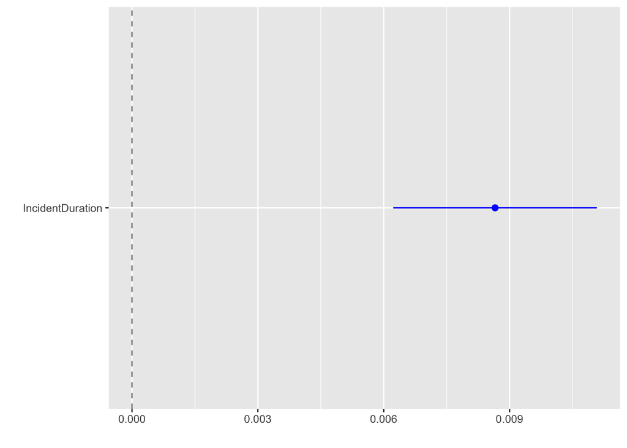

```r
req_SLR_bp <- broom.mixed::tidy(req_SLR_fit) %>%
                dotwhisker::dwplot(dot_args = list(size = 2, color = "blue"),
                                   whisker_args = list(color = "blue"),
                                   vline = geom_vline(xintercept = 0, colour = "grey50", linetype = 2))
req_SLR_bp
```

```r
#save image
req_SLR_bp_file = here("results","req_SLR_bp.png")
ggsave(filename = req_SLR_bp_file, plot = req_SLR_bp)
```

Predict requested funds from FEMA based on the model above for the training data set.

```r
#use predict to predict funds
stats::predict(req_SLR_fit, req_train_data)
```

```
## # A tibble: 244 × 1
##    .pred
##    <dbl>
##  1  11.9
##  2  17.6
##  3  12.0
##  4  12.2
##  5  17.6
##  6  11.9
##  7  12.2
##  8  12.0
##  9  17.6
## 10  11.9
## # … with 234 more rows
```

```r
#create df with model predictions and actual measures
req_SLR_aug <- augment(req_SLR_fit, req_train_data)

#add labeling variables for later summarization
req_SLR_train <- req_SLR_aug %>%
                    dplyr::mutate(data = "train",
                                  model = "SLR")
```

Assess goodness of fit measures.

```r
#using glace
modelsummary::glance(req_SLR_fit)
```

```
## # A tibble: 1 × 12
##   r.squared adj.r.squared sigma statistic  p.value    df logLik   AIC   BIC
##       <dbl>         <dbl> <dbl>     <dbl>    <dbl> <dbl>  <dbl> <dbl> <dbl>
## 1     0.168         0.164  4.62      48.8 2.71e-11     1  -719. 1443. 1454.
## # … with 3 more variables: deviance <dbl>, df.residual <int>, nobs <int>
```

```r
#using the prediction capacity
req_SLR_train %>% yardstick::metrics(truth = logReqAmt, estimate = .pred)
```

```
## # A tibble: 3 × 3
##   .metric .estimator .estimate
##   <chr>   <chr>          <dbl>
## 1 rmse    standard       4.60
## 2 rsq     standard       0.168
## 3 mae     standard       2.49
```

This isn’t a great model. Time to try adding more predictors.

### Multivariable Linear Regression

Create the MVR using the `tidymodels` setup.

```r
#define linear mod
lr_mod <- linear_reg() %>%
              set_engine("lm")

#define recipe
req_MVR_rec <- recipes::recipe(logReqAmt ~ ., data = req_train_data)

#define SLR workflow
req_MVR_wflow <- workflows::workflow() %>%
                   workflows::add_model(lr_mod) %>%
                   workflows::add_recipe(req_MVR_rec)

#fit the training data to the workflow
req_MVR_fit <- req_MVR_wflow %>%
                  parsnip::fit(data = req_train_data)

#create tibble for model fit using broom and extract
req_MVR_fit %>%
  workflowsets::extract_fit_parsnip() %>%
  broom::tidy()
```

```
## # A tibble: 95 × 5
##    term         estimate std.error statistic p.value
##    <chr>           <dbl>     <dbl>     <dbl>   <dbl>
##  1 (Intercept) -163.        485.     -0.335    0.738
##  2 stateAL        0.105       3.72    0.0283   0.977
##  3 stateAR       -1.16        3.52   -0.329    0.743
##  4 stateAZ        0.0779      4.58    0.0170   0.986
##  5 stateCA        0.847       3.41    0.248    0.804
##  6 stateCO        0.242       3.46    0.0701   0.944
##  7 stateCT       -1.03        4.01   -0.257    0.797
##  8 stateDC        3.99        5.81    0.687    0.493
##  9 stateDE        0.0670      5.10    0.0131   0.990
## 10 stateFL       -0.191       3.38   -0.0565   0.955
## # … with 85 more rows
```

Create box and whisker plot for the fit output.

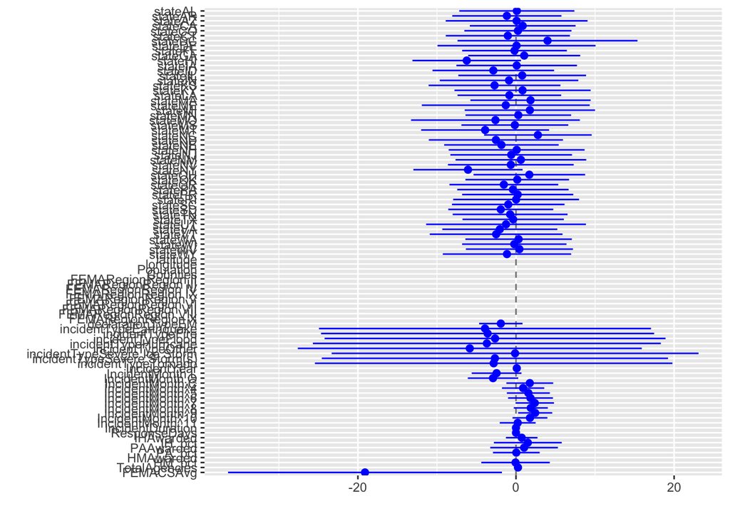

```r
#basic box and whisker plot
req_MVR_bp <- broom.mixed::tidy(req_MVR_fit) %>%
                dotwhisker::dwplot(dot_args = list(size = 2, color = "blue"),
                                   whisker_args = list(color = "blue"),
                                   vline = geom_vline(xintercept = 0, colour = "grey50", linetype = 2))
req_MVR_bp
```

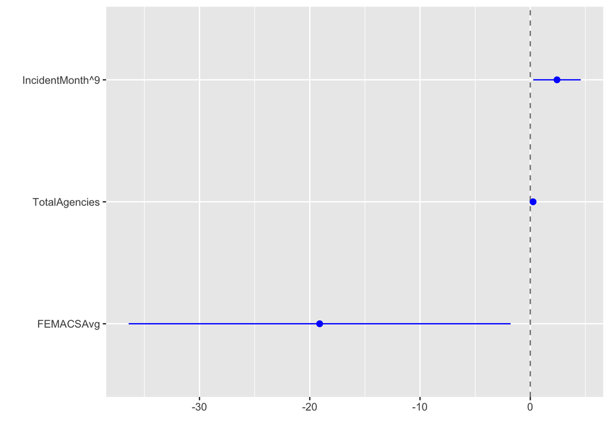

```r
#there's a lot of information here, but hard to identify the ones that are significant due to volume

#box and whisker plot for significant predictors
#first filter significant results
req_MVR_fit_sig <- broom.mixed::tidy(req_MVR_fit) %>%
                      dplyr::filter(p.value < 0.05)

#box and whisker plot for lm_fit2 significant predictors
req_MVR_fit_bp2 <- req_MVR_fit_sig %>%
                        dotwhisker::dwplot(dot_args = list(size = 2, color = "blue"),
                                           whisker_args = list(color = "blue"),
                                           vline = geom_vline(xintercept = 0, colour = "grey50", linetype = 2))
req_MVR_fit_bp2
```

```r
#save file
req_MVR_bp_file = here("results","req_MVR_bp.png")
ggsave(filename = req_MVR_bp_file, plot = req_MVR_fit_bp2)
```

Predict requested funds from FEMA based on the model above for the training data set.

```r
#use predict to predict funds
stats::predict(req_MVR_fit, req_train_data)
```

```
## # A tibble: 244 × 1
##    .pred
##    <dbl>
##  1  9.25
##  2 15.3
##  3  4.10
##  4 14.4
##  5 17.1
##  6  5.87
##  7 13.6
##  8 12.3
##  9 15.6
## 10 15.1
## # … with 234 more rows
```

```r
#create df with model predictions and actual measures
req_MVR_aug <- augment(req_MVR_fit, req_train_data)
#add labeling variables for later summarization
req_MVR_train <- req_MVR_aug %>%
                    dplyr::mutate(data = "train",
                                  model = "MVR")
```

Assess goodness of fit measures.

```r
#using glace
modelsummary::glance(req_MVR_fit)
```

```
## # A tibble: 1 × 12
##   r.squared adj.r.squared sigma statistic      p.value    df logLik   AIC   BIC
##       <dbl>         <dbl> <dbl>     <dbl>        <dbl> <dbl>  <dbl> <dbl> <dbl>
## 1     0.577         0.369  4.02      2.77 0.0000000188    80  -636. 1436. 1723.
## # … with 3 more variables: deviance <dbl>, df.residual <int>, nobs <int>
```

```r
#using the prediction capacity
req_MVR_train %>% yardstick::metrics(truth = logReqAmt, estimate = .pred)
```

```
## # A tibble: 3 × 3
##   .metric .estimator .estimate
##   <chr>   <chr>          <dbl>
## 1 rmse    standard       3.28
## 2 rsq     standard       0.577
## 3 mae     standard       1.87
```

While this is an improvement, it’s still not a great model. Let’s compare the two side-by-side using RMSE.

### Requested Funds: Model Evaluation

Formally compare the two linear models

```r
#First create comprehensive df with all of the predictions
req_lm_preds <- bind_rows(req_MVR_train,
                          req_SLR_train)

#Use the yardstick package to calculate the metrics on resamples
req_lm_metrics <- req_lm_preds %>%
                      dplyr::group_by(data, model) %>%
                      yardstick::metrics(truth = logReqAmt, estimate = .pred)

#for interpretation: rmse = Root Mean Squared Error (RMSE), rsq = R^2, mae = Mean Absolute Error (MAE)
#make a df that displays RMSE and R^2 for each model and data (all dplyr functions)
req_lm_RMSE <- req_lm_metrics %>%
                    filter(.metric == "rmse" | .metric == "rsq") %>%
                    select(-c(.estimator, data))

#save comparison table
req_lm_eval_file = here("results", "lm-req-lm-eval.Rds")
saveRDS(req_lm_RMSE, file = req_lm_eval_file)
```

In comparing the two models, the full model certainly improves the fit, but neither is ideal. Alternative models should be considered.

## Outcome of Interest: Obligated FEMA Funds

We will now examine obligated FEMA funds as the outcome of interest.

### Data Set Up

```r
#fix random numbers by setting the seed (helps reproducibility)
set.seed(123)

#put 3/4 of data into the training set
obl_data_split <- rsample::initial_split(obl_data, prop = 3/4)

#create dataframes for the two sets
obl_train_data <- rsample::training(obl_data_split)
obl_test_data <- rsample::testing(obl_data_split)
```

### Simple Linear Regression

Create the SLR using the `tidymodels` setup.

```r
#define lr mod
lr_mod <- parsnip::linear_reg() %>%
          parsnip::set_engine("lm")

#define recipe
obl_SLR_rec <- recipes::recipe(logOblAmt ~ IncidentDuration, data = obl_train_data)

#define SLR workflow
obl_SLR_wflow <- workflows::workflow() %>%
                   workflows::add_model(lr_mod) %>%
                   workflows::add_recipe(obl_SLR_rec)

#fit the training data to the workflow
obl_SLR_fit <- obl_SLR_wflow %>%
                  parsnip::fit(data = obl_train_data)

#create tibble for model fit using broom and extract
obl_SLR_fit %>%
  workflowsets::extract_fit_parsnip() %>%
  broom::tidy()
```

```
## # A tibble: 2 × 5
##   term             estimate std.error statistic  p.value
##   <chr>               <dbl>     <dbl>     <dbl>    <dbl>
## 1 (Intercept)      11.9       0.333       35.6  3.11e-98
## 2 IncidentDuration  0.00864   0.00124      6.97 2.98e-11
```

Create box and whisker plot for the fit output.

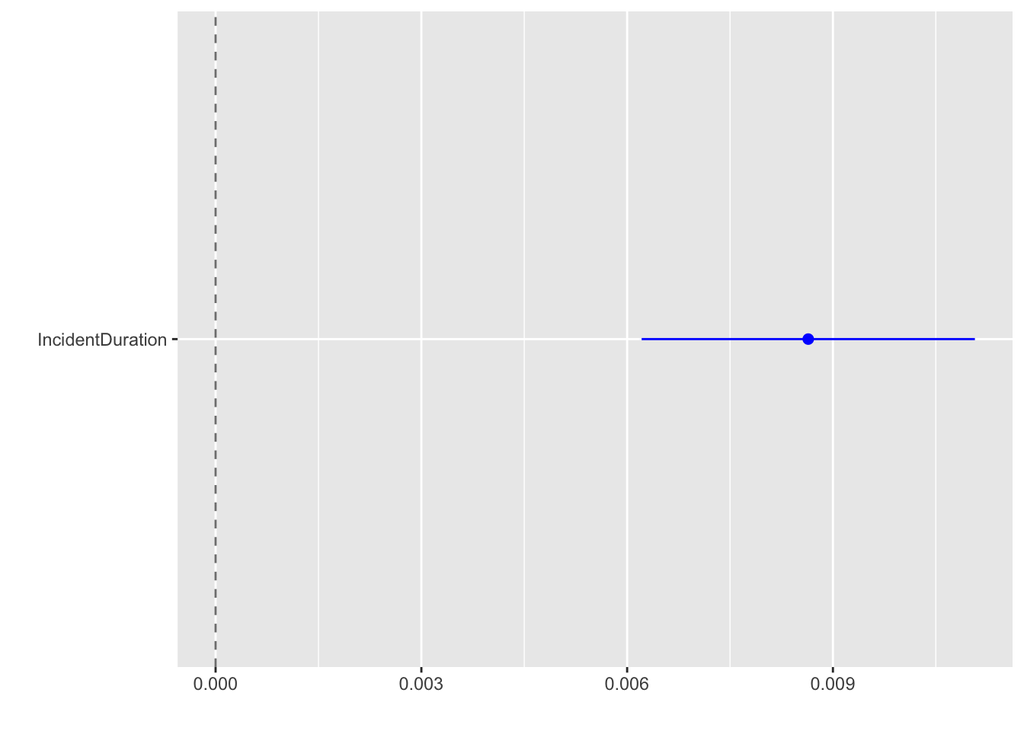

```r
obl_SLR_bp <- broom.mixed::tidy(obl_SLR_fit) %>%
                dotwhisker::dwplot(dot_args = list(size = 2, color = "blue"),
                                   whisker_args = list(color = "blue"),
                                   vline = geom_vline(xintercept = 0, colour = "grey50", linetype = 2))
obl_SLR_bp
```

```r
#save image
obl_SLR_bp_file = here("results","obl_SLR_bp.png")
ggsave(filename = obl_SLR_bp_file, plot = obl_SLR_bp)
```

Predict requested funds from FEMA based on the model above for the training data set.

```r
#use predict to predict funds
stats::predict(obl_SLR_fit, obl_train_data)
```

```
## # A tibble: 244 × 1
##    .pred
##    <dbl>
##  1  11.9
##  2  17.6
##  3  12.0
##  4  12.2
##  5  17.6
##  6  11.9
##  7  12.2
##  8  12.1
##  9  17.6
## 10  11.9
## # … with 234 more rows
```

```r
#create df with model predictions and actual measures
obl_SLR_aug <- augment(obl_SLR_fit, obl_train_data)

#add labeling variables for later summarization
obl_SLR_train <- obl_SLR_aug %>%
                    dplyr::mutate(data = "train",
                                  model = "SLR")
```

Assess goodness of fit measures.

```r
#using glace
modelsummary::glance(obl_SLR_fit)
```

```
## # A tibble: 1 × 12
##   r.squared adj.r.squared sigma statistic  p.value    df logLik   AIC   BIC
##       <dbl>         <dbl> <dbl>     <dbl>    <dbl> <dbl>  <dbl> <dbl> <dbl>
## 1     0.167         0.164  4.62      48.6 2.98e-11     1  -719. 1444. 1454.
## # … with 3 more variables: deviance <dbl>, df.residual <int>, nobs <int>
```

```r
#using the prediction capacity
obl_SLR_train %>% yardstick::metrics(truth = logOblAmt, estimate = .pred)
```

```
## # A tibble: 3 × 3
##   .metric .estimator .estimate
##   <chr>   <chr>          <dbl>
## 1 rmse    standard       4.60
## 2 rsq     standard       0.167
## 3 mae     standard       2.50
```

This isn’t a great model. Time to try adding more predictors.

### Multivariable Linear Regression

Create the MVR using the `tidymodels` setup.

```r
#define linear mod
lr_mod <- linear_reg() %>%
              set_engine("lm")

#define recipe
obl_MVR_rec <- recipes::recipe(logOblAmt ~ ., data = obl_train_data)

#define SLR workflow
obl_MVR_wflow <- workflows::workflow() %>%
                   workflows::add_model(lr_mod) %>%
                   workflows::add_recipe(obl_MVR_rec)

#fit the training data to the workflow
obl_MVR_fit <- obl_MVR_wflow %>%
                  parsnip::fit(data = obl_train_data)

#create tibble for model fit using broom and extract
obl_MVR_fit %>%
  workflowsets::extract_fit_parsnip() %>%
  broom::tidy()
```

```
## # A tibble: 95 × 5
##    term         estimate std.error statistic p.value
##    <chr>           <dbl>     <dbl>     <dbl>   <dbl>
##  1 (Intercept) -162.        485.     -0.333    0.739
##  2 stateAL        0.131       3.72    0.0353   0.972
##  3 stateAR       -1.14        3.52   -0.324    0.747
##  4 stateAZ        0.0629      4.58    0.0137   0.989
##  5 stateCA        0.850       3.41    0.249    0.804
##  6 stateCO        0.243       3.46    0.0703   0.944
##  7 stateCT       -1.02        4.01   -0.255    0.799
##  8 stateDC        3.94        5.81    0.679    0.498
##  9 stateDE        0.0825      5.10    0.0162   0.987
## 10 stateFL       -0.172       3.38   -0.0509   0.960
## # … with 85 more rows
```

Create box and whisker plot for the fit output.

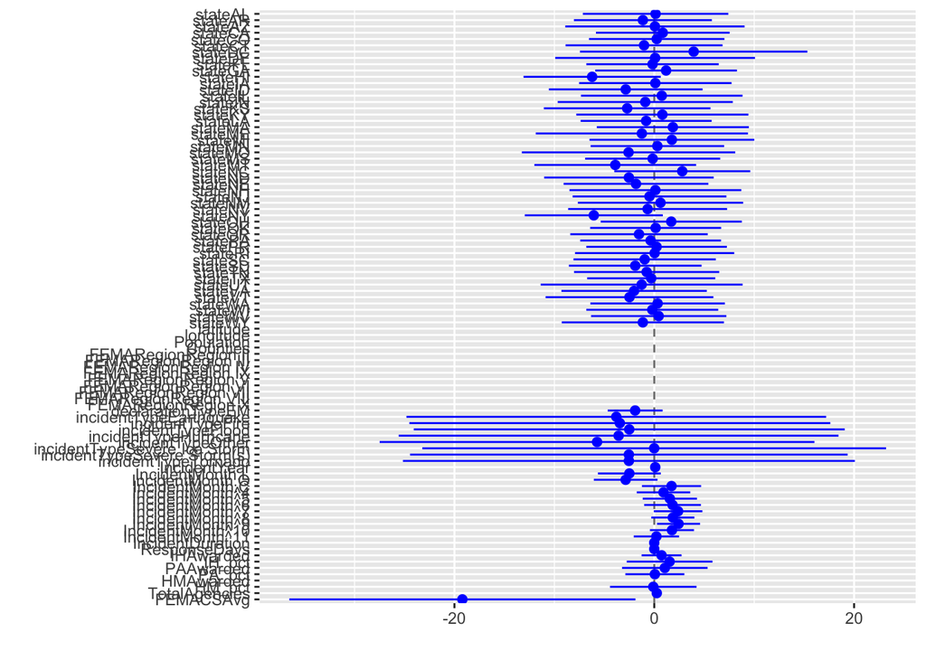

```r
#basic box and whisker plot
obl_MVR_bp <- broom.mixed::tidy(obl_MVR_fit) %>%
                dotwhisker::dwplot(dot_args = list(size = 2, color = "blue"),
                                   whisker_args = list(color = "blue"),
                                   vline = geom_vline(xintercept = 0, colour = "grey50", linetype = 2))
obl_MVR_bp
```

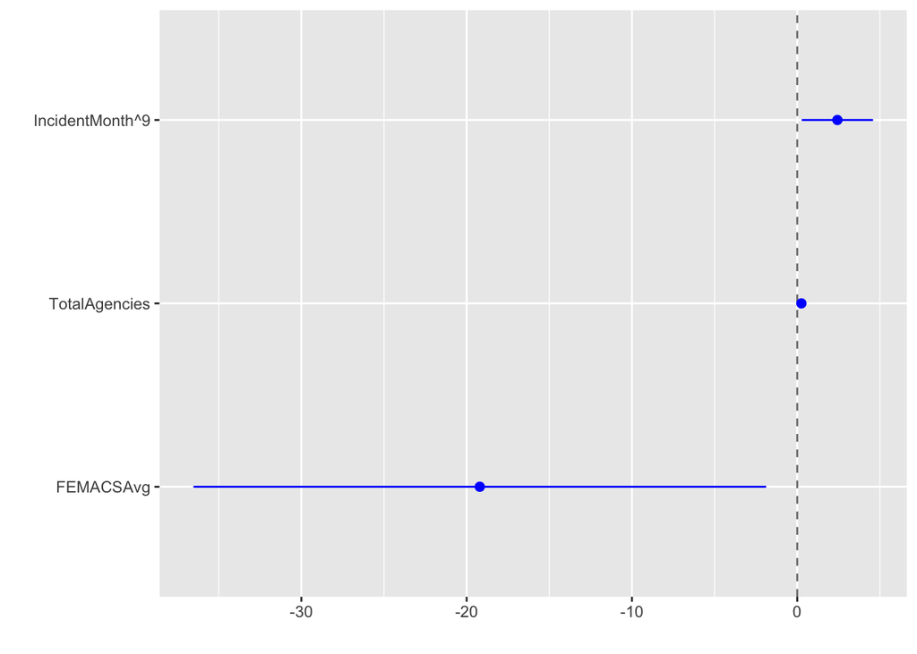

```r
#there's a lot of information here, but hard to identify the ones that are significant due to volume

#box and whisker plot for significant predictors
#first filter significant results
obl_MVR_fit_sig <- broom.mixed::tidy(obl_MVR_fit) %>%
                      dplyr::filter(p.value < 0.05)

#box and whisker plot for lm_fit2 significant predictors
obl_MVR_fit_bp2 <- obl_MVR_fit_sig %>%
                        dotwhisker::dwplot(dot_args = list(size = 2, color = "blue"),
                                           whisker_args = list(color = "blue"),
                                           vline = geom_vline(xintercept = 0, colour = "grey50", linetype = 2))
obl_MVR_fit_bp2
```

```r
#save file
obl_MVR_bp_file = here("results","obl_MVR_bp.png")
ggsave(filename = obl_MVR_bp_file, plot = obl_MVR_fit_bp2)
```

Predict obligated funds from FEMA based on the model above for the training data set.

```r
#use predict to predict funds
stats::predict(obl_MVR_fit, obl_train_data)
```

```
## # A tibble: 244 × 1
##    .pred
##    <dbl>
##  1  9.23
##  2 15.3
##  3  4.11
##  4 14.4
##  5 17.1
##  6  5.84
##  7 13.6
##  8 12.3
##  9 15.6
## 10 15.1
## # … with 234 more rows
```

```r
#create df with model predictions and actual measures
obl_MVR_aug <- augment(obl_MVR_fit, obl_train_data)
#add labeling variables for later summarization
obl_MVR_train <- obl_MVR_aug %>%
                    dplyr::mutate(data = "train",
                                  model = "MVR")
```

Assess goodness of fit measures.

```r
#using glace
modelsummary::glance(obl_MVR_fit)
```

```
## # A tibble: 1 × 12
##   r.squared adj.r.squared sigma statistic      p.value    df logLik   AIC   BIC
##       <dbl>         <dbl> <dbl>     <dbl>        <dbl> <dbl>  <dbl> <dbl> <dbl>
## 1     0.577         0.369  4.02      2.78 0.0000000183    80  -636. 1436. 1723.
## # … with 3 more variables: deviance <dbl>, df.residual <int>, nobs <int>
```

```r
#using the prediction capacity
obl_MVR_train %>% yardstick::metrics(truth = logOblAmt, estimate = .pred)
```

```
## # A tibble: 3 × 3
##   .metric .estimator .estimate
##   <chr>   <chr>          <dbl>
## 1 rmse    standard       3.28
## 2 rsq     standard       0.577
## 3 mae     standard       1.87
```

While this is an improvement, it’s still not a great model. Let’s compare the two side-by-side using RMSE.

### Obligated Funds: Model Evaluation

Formally compare the two linear models

```r
#First create comprehensive df with all of the predictions
obl_lm_preds <- bind_rows(obl_MVR_train,
                          obl_SLR_train)

#Use the yardstick package to calculate the metrics on resamples
obl_lm_metrics <- obl_lm_preds %>%
                      dplyr::group_by(data, model) %>%
                      yardstick::metrics(truth = logOblAmt, estimate = .pred)

#for interpretation: rmse = Root Mean Squared Error (RMSE), rsq = R^2, mae = Mean Absolute Error (MAE)
#make a df that displays RMSE and R^2 for each model and data (all dplyr functions)
obl_lm_RMSE <- obl_lm_metrics %>%
                    filter(.metric == "rmse" | .metric == "rsq") %>%
                    select(-c(.estimator, data))

#save comparison table
obl_lm_eval_file = here("results", "lm-obl-lm-eval.Rds")
saveRDS(obl_lm_RMSE, file = obl_lm_eval_file)
```

In comparing the two models, the full model certainly improves the fit, but neither is ideal. Alternative models should be considered.

## Compare Requested and Obligated Models

As one last step for the linear models, let’s compare the metrics from the obligated and requested funds models.

```r
#add outcome labels
req_lm_RMSE$outcome <- "Requested"
obl_lm_RMSE$outcome <- "Obligated"

#combine into one table
lm_comp <- dplyr::bind_rows(req_lm_RMSE,
                            obl_lm_RMSE)

#clean up the table
lm_comp$label <- paste(lm_comp$model, lm_comp$.metric, sep=": ")

lm_comp_tbl <- lm_comp %>%
                  subset(select = -c(1:2))

lm_comp_table <- xtabs(.estimate ~ label + outcome, lm_comp_tbl)
lm_comp_table
```

```
##            outcome
## label       Obligated Requested
##   MVR: rmse 3.2825340 3.2821346
##   MVR: rsq  0.5767613 0.5765888
##   SLR: rmse 4.6045374 4.6012644
##   SLR: rsq  0.1672034 0.1678456
```

```r
#save file
lm_eval_file = here("results", "lm-eval.Rds")
saveRDS(lm_comp_table, file = lm_eval_file)
```

The two outcomes yield virtually identical models.